# TMT_MS_and_RNAseq_plotting_forGithub

## Plotting the TMT MS and RNAseq data

This Python notebook includes the code that was used to plot the proteome and transcriptome remodeling in DNA limited cells

**Publication:** Genome concentration limits cell growth and modulates proteome composition in *Escherichia coli*

**Authors:** Jarno Mäkelä$^{1,2,3,†}$, Alexandros Papagiannakis$^{1,2,†}$, Wei-Hsiang Lin$^{1,2,\&}$, Michael C. Lanz$^{4,5,\&}$, Skye Glenn$^{2,4}$, Matthew Swaffer$^{4,¶}$, Georgi K. Marinov$^{6}$, Jan M. Skotheim$^{4,5}$, Christine Jacobs-Wagner$^{1,2,4,*}$

**Affiliations and contributions:**  
$^{1}$Howard Hughes Medical Institute, Stanford University, Stanford, CA 94305, USA

$^{2}$Sarafan Chemistry, Engineering, and Medicine for Human Health Institute, Stanford University, Stanford, CA 94305, USA

$^{3}$Institute of Biotechnology, Helsinki Institute of Life Science, University of Helsinki, Helsinki, Finland

$^{4}$Department of Biology, Stanford University, Stanford, CA 94305, USA

$^{5}$Chan Zuckerberg Biohub, Stanford, CA 94305, USA

$^{6}$Department of Genetics, Stanford University, Stanford, CA 94305, USA

$^{¶}$Current address: Wellcome Centre for Cell Biology, University of Edinburgh, Edinburgh, EH9 3BF, UK

$^{†}$These authors contributed equally to this work.

$^{\&}$These authors contributed equally to this work.

*For correspondence: jacobs-wagner@stanford.edu

**Developer:**  
Developed by Alexandros Papagiannakis (alexpapa@staford.edu), Stanford University / Howard Hughes Medical Institute, Christine Jacobs-Wagner lab 2024.

**TMT MS data generated** by Jarno Mäkelä and Michael C. Lanz

**RNAseq data generated** by Skye Glenn, Matthew Swaffer and Georgi K. Marinov

```python
import pandas as pd
import numpy as np
import matplotlib.pyplot as plt
import seaborn as sns
import scipy as sp
from scipy.stats import spearmanr, gaussian_kde
import pickle
import skimage
import os
import matplotlib
from sklearn.decomposition import PCA
import warnings
warnings.filterwarnings("ignore")
import matplotlib
```

### Loading the data

```python
prot_data_path =r"...\Dataset_1.xlsx"
rna_data_path  = r"...\Dataset_2.txt"

prot_data_index = pd.read_excel(prot_data_path,
                         sheet_name = 'Index')

prot_data_main = pd.read_excel(prot_data_path,
                         sheet_name = 'Main')

prot_data_exp1 = pd.read_excel(prot_data_path,
                         sheet_name = 'Exp #1')

prot_data_exp2 = pd.read_excel(prot_data_path,
                         sheet_name = 'Exp #2')

prot_data_misc = pd.read_excel(prot_data_path,
                         sheet_name = 'Misc')

rna_data = pd.read_table(rna_data_path)

save_path_dir = "None"
```

### Helper functions

```python
def principal_component_regression(x, y):
    """
    Resources:
    https://scikit-learn.org/stable/auto_examples/cross_decomposition/plot_pcr_vs_pls.html
    """
    x_scaled = (x-np.mean(x))/np.std(x)
    y_scaled = (y-np.mean(y))/np.std(y)
    x_stack = np.column_stack((list(x_scaled),list(y_scaled)))
    pca = PCA(n_components=2).fit(x_stack)
    for i, (comp, var) in enumerate(zip(pca.components_, pca.explained_variance_)):
        if i == 0:  # The first component explains most of the variance
#             print(comp, var)
            comp = comp * var  # scale component by its variance explanation power
            lin_fit = np.polyfit([0, comp[0]],[0, comp[1]],1)
            fit_x = np.arange(-2,2,0.01)
            y_hat = np.polyval(lin_fit, fit_x)
    return np.polyfit(fit_x*np.std(x)+np.mean(x), y_hat*np.std(y)+np.mean(y), 1)


def density_scatter(x,y):
    xy = np.vstack([x,y])
    z = gaussian_kde(xy)(xy)
    return z
```

```python
def get_protein_slope_dict(dataframe):

    onen_dict = pd.Series(dataframe['Protien Slope (1-N)'].values, index=dataframe.Uniprot).to_dict()
    mltn_dict = pd.Series(dataframe['Protien Slope (multi-N)'].values, index=dataframe.Uniprot).to_dict()

    return onen_dict, mltn_dict

def assemgle_protein_slope_dataframe(dataframe_exp1, dataframe_exp2):

    onen_dict_exp1, mltn_dict_exp1 = get_protein_slope_dict(dataframe_exp1)
    onen_dict_exp2, mltn_dict_exp2 = get_protein_slope_dict(dataframe_exp2)

    slope_df = pd.DataFrame()
    slope_df['Uniprot'] = np.unique(list(onen_dict_exp1.keys())+list(onen_dict_exp2.keys()))
    slope_df['slope_1N_exp1'] = slope_df.Uniprot.map(onen_dict_exp1)
    slope_df['slope_1N_exp2'] = slope_df.Uniprot.map(onen_dict_exp2)
    slope_df['slope_mltN_exp1'] = slope_df.Uniprot.map(mltn_dict_exp1)
    slope_df['slope_mltN_exp2'] = slope_df.Uniprot.map(mltn_dict_exp2)

    return slope_df

def get_ion_intensity_and_ori_distance(misc_df, slope_df):

    ori_dict = pd.Series(misc_df['Circular distance from oriC'].values, index = misc_df['Entry']).to_dict()
    ion_dict = pd.Series(misc_df['Summed ion intensity / Length'].values, index = misc_df['Entry']).to_dict()

    slope_df['ori_distance'] = slope_df.Uniprot.map(ori_dict)
    slope_df['ion_intensity'] = slope_df.Uniprot.map(ion_dict)
    slope_df['mean_slope_1N'] = (slope_df['slope_1N_exp1']+slope_df['slope_1N_exp2'])/2
    slope_df['mean_slope_mltN'] = (slope_df['slope_mltN_exp1']+slope_df['slope_mltN_exp2'])/2

    return slope_df
```

```python
def get_ori_distance_for_rna(prot_misc_df, rna_df):

    intensity_dict = pd.Series(prot_misc_df['Summed ion intensity'].values, index=prot_misc_df['Gene name']).to_dict()
    intensity_length_dict = pd.Series(prot_misc_df['Summed ion intensity / Length'].values, index=prot_misc_df['Gene name']).to_dict()
    ori_dict = pd.Series(prot_misc_df['Circular distance from oriC'].values, index=prot_misc_df['Gene name']).to_dict()

    rna_df['summed_ion_intensity'] = rna_df.gene_name.map(intensity_dict)
    rna_df['summed_ion_intensity_per_length'] = rna_df.gene_name.map(intensity_length_dict)
    rna_df['circular_ori_distance'] = rna_df.gene_name.map(ori_dict)
    rna_df['gene_length'] = rna_df.summed_ion_intensity/rna_df.summed_ion_intensity_per_length

    return rna_df
```

### The distributions of protein and RNA slopes

The plots below show the scaling of the relative protein and RNA concentration with cell area. A Gaussian kernel density estimation is used to illustrate the data density.

```python
protein_slope_df = assemgle_protein_slope_dataframe(prot_data_exp1, prot_data_exp2)
```

```python
def plot_protein_experiment_slope_comparison(slope_df, save_path):

    slope_df['mean_slope_1N'] = (slope_df['slope_1N_exp1']+slope_df['slope_1N_exp2'])/2
    slope_df['mean_slope_mltN'] = (slope_df['slope_mltN_exp1']+slope_df['slope_mltN_exp2'])/2
#     slope_df = slope_df[slope_df.ion_intensity>0]
    plt.figure(figsize=(18,4))
    gs = matplotlib.gridspec.GridSpec(1, 9, height_ratios=[1], width_ratios=[1,0.1,0.2]*3)
    gss = [plt.subplot(gs[0,0]),
           plt.subplot(gs[0,1]),
           plt.subplot(gs[0,3]),
           plt.subplot(gs[0,4]),
           plt.subplot(gs[0,6]),
           plt.subplot(gs[0,7])]


    onen_axis = gss[0]
    onen_density_axis = gss[1]
    mltn_axis = gss[2]
    mltn_density_axis = gss[3]
    comp_axis = gss[4]
    comp_density_axis = gss[5]

    xone = slope_df.slope_1N_exp1
    yone = slope_df.slope_1N_exp2
    zone = density_scatter(xone, yone)
    print('1N-rich',spearmanr(xone, yone))
    xmlt = slope_df.slope_mltN_exp1
    ymlt = slope_df.slope_mltN_exp2
    zmlt = density_scatter(xmlt, ymlt)
    print('multi-N',spearmanr(xmlt, ymlt))
    xcom = slope_df.mean_slope_1N
    ycom = slope_df.mean_slope_mltN
    zcom = density_scatter(xcom, ycom)
#     print('1N/multi-N',spearmanr(xcom, ycom))

    fig_one = onen_axis.scatter(xone, yone, c=zone, cmap='cividis', s=2)
    onen_axis.set_title('1N-rich cells')
    onen_axis.axhline(0, linewidth=0.5, color='black')
    onen_axis.axvline(0, linewidth=0.5, color='black')
    onen_axis.set_xlim(-2.5,2.5)
    onen_axis.set_ylim(-2.5,2.5)

    fig_mlt = mltn_axis.scatter(xmlt, ymlt, c=zmlt, cmap='cividis', s=2)
    mltn_axis.set_title('multi-N cells')
    mltn_axis.axhline(0, linewidth=0.5, color='black')
    mltn_axis.axvline(0, linewidth=0.5, color='black')
    mltn_axis.set_xlim(-2.5,2.5)
    mltn_axis.set_ylim(-2.5,2.5)


    fig_com = comp_axis.scatter(xcom, ycom, c=zcom, cmap='cividis', s=2)
    comp_axis.axhline(0, linewidth=0.5, color='black')
    comp_axis.axvline(0, linewidth=0.5, color='black')
    comp_axis.set_xlim(-2.5,2.5)
    comp_axis.set_ylim(-2.5,2.5)


    print(round(xcom[xcom>=0.2].shape[0]/xcom.shape[0]*100,0), '% of 1N-rich slopes above 0.2')
    print(round(xcom[xcom<=-0.2].shape[0]/xcom.shape[0]*100,0), '% of 1N-rich slopes below -0.2')
    print(round(ycom[ycom>=0.2].shape[0]/ycom.shape[0]*100,0), '% of multi-N slopes above 0.2')
    print(round(ycom[ycom<=-0.2].shape[0]/ycom.shape[0]*100,0), '% of multi-N slopes below -0.2')

    print(xcom[xcom>=0.2].shape[0], '1N-rich slopes above 0.2')
    print(xcom[xcom<=-0.2].shape[0], '1N-rich slopes below -0.2')
    print(xcom.shape[0], 'total proteins in 1N cells')
    print(ycom[ycom>=0.2].shape[0], 'multi-N slopes above 0.2')
    print(ycom[ycom<=-0.2].shape[0], 'multi-N slopes below -0.2')
    print(ycom.shape[0], 'total proteins in multi-N cells')


    cbar_one = plt.colorbar(fig_one, cax=onen_density_axis)
    cbar_one.set_label('Density', rotation=90, fontsize=14, fontweight='bold')
    cbar_mlt = plt.colorbar(fig_mlt, cax=mltn_density_axis)
    cbar_mlt.set_label('Density', rotation=90, fontsize=14, fontweight='bold')
    cbar_com = plt.colorbar(fig_com, cax=comp_density_axis)
    cbar_com.set_label('Density', rotation=90, fontsize=14, fontweight='bold')

    mltn_axis.set_xlabel('Protein slope - Exp #1', fontsize=14, fontweight='bold')
    mltn_axis.set_ylabel('Protein slope - Exp #2', fontsize=14, fontweight='bold')

    onen_axis.set_xlabel('Protein slope - Exp #1', fontsize=14, fontweight='bold')
    onen_axis.set_ylabel('Protein slope - Exp #2', fontsize=14, fontweight='bold')

    comp_axis.set_xlabel('Protein slope - 1N-rich cells', fontsize=14, fontweight='bold')
    comp_axis.set_ylabel('Protein slope - multi-N cells', fontsize=14, fontweight='bold')

    if os.path.isdir(save_path):
        print('saving...')
        plt.savefig(save_path+'/proteomics_slope_replicate_comparison.eps')
    plt.show()
```

```
1N-rich SpearmanrResult(correlation=0.9052744268255005, pvalue=0.0)
multi-N SpearmanrResult(correlation=0.45925456350216926, pvalue=1.828050739493121e-123)
24.0 % of 1N-rich slopes above 0.2
39.0 % of 1N-rich slopes below -0.2
3.0 % of multi-N slopes above 0.2
3.0 % of multi-N slopes below -0.2
570 1N-rich slopes above 0.2
931 1N-rich slopes below -0.2
2360 total proteins in 1N cells
66 multi-N slopes above 0.2
77 multi-N slopes below -0.2
2360 total proteins in multi-N cells
```

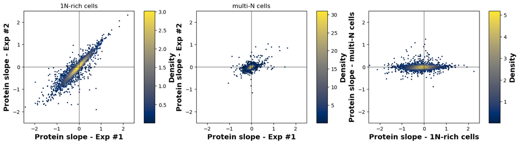

```python
plot_protein_experiment_slope_comparison(protein_slope_df, save_path_dir)
```

```python
def plot_rna_experiment_slope_comparison(rna_dataframe, save_path):

    def remove_nans(x, y):
        plot_df = pd.DataFrame()
        plot_df['x'] = x
        plot_df['y'] = y
        plot_df = plot_df.dropna()
        return plot_df.x, plot_df.y


    plt.figure(figsize=(12,4))
    gs = matplotlib.gridspec.GridSpec(1, 6, height_ratios=[1], width_ratios=[1,0.1,0.2]*2)
    gss = [plt.subplot(gs[0,0]),
           plt.subplot(gs[0,1]),
           plt.subplot(gs[0,3]),
           plt.subplot(gs[0,4])]

    one_axis = gss[0]
    one_density_axis = gss[1]
    two_axis = gss[2]
    two_density_axis = gss[3]

    xone = rna_dataframe['RNA_slope_exp230501']
    yone = rna_dataframe['RNA_slope_exp230502']
    xone, yone = remove_nans(xone, yone)
    zone = density_scatter(xone, yone)
    print('Copmarison of RNAseq replciates',spearmanr(xone, yone))

    xtwo = rna_dataframe['RNA_slope']
    ytwo = rna_dataframe['mean_protein_slope_1N']
    xtwo, ytwo = remove_nans(xtwo, ytwo)
    ztwo = density_scatter(xtwo, ytwo)
    print('Comparison of mRNA and protein slopes', spearmanr(xtwo, ytwo))

    fig_one = one_axis.scatter(xone, yone, c=zone, cmap='cividis', s=2)
    one_axis.axhline(0, linewidth=0.5, color='black')
    one_axis.axvline(0, linewidth=0.5, color='black')
    one_axis.set_xlim(-3.5,3.5)
    one_axis.set_ylim(-3.5,3.5)
    print(xone.shape[0], 'mRNAs detected')
    fig_two = two_axis.scatter(xtwo, ytwo, c=ztwo, cmap='cividis', s=2)
    print(xtwo.shape[0], 'mRNA - protein slope pairs')
    pcr = principal_component_regression(xtwo, ytwo)
    x_pcr = np.arange(-3.5,3.51,0.01)
    print('Principal component regression:', pcr)
#     print('Univariate fit:', np.polyfit(xtwo, ytwo, 1))
#     two_axis.plot(x_pcr, np.polyval(pcr, x_pcr), color='black', linewidth=2)
    two_axis.axhline(0, linewidth=0.5, color='black')
    two_axis.axvline(0, linewidth=0.5, color='black')
    two_axis.set_xlim(-3.5,3.5)
    two_axis.set_ylim(-3.5,3.5)

    cbar_one = plt.colorbar(fig_one, cax=one_density_axis)
    cbar_one.set_label('Density', rotation=90, fontsize=14, fontweight='bold')
    cbar_two = plt.colorbar(fig_two, cax=two_density_axis)
    cbar_two.set_label('Density', rotation=90, fontsize=14, fontweight='bold')

    two_axis.set_xlabel('RNA slope', fontsize=14, fontweight='bold')
    two_axis.set_ylabel('Protein slope', fontsize=14, fontweight='bold')

    one_axis.set_xlabel('RNA slope - Exp #1', fontsize=14, fontweight='bold')
    one_axis.set_ylabel('RNA slope - Exp #2', fontsize=14, fontweight='bold')

    if os.path.isdir(save_path):
        print('saving...')
        plt.savefig(save_path+'/proteomics_transcriptomics_slope_comparison.eps')
    plt.show()
```

```
Copmarison of RNAseq replciates SpearmanrResult(correlation=0.9081738724212977, pvalue=0.0)
Comparison of mRNA and protein slopes SpearmanrResult(correlation=0.7599585406660536, pvalue=0.0)
3446 mRNAs detected
2324 mRNA - protein slope pairs
Principal component regression: [ 0.56910682 -0.03933793]
```

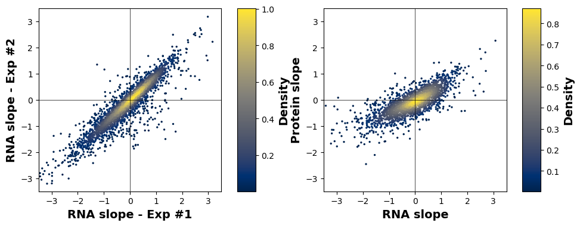

```python
plot_rna_experiment_slope_comparison(rna_data, save_path_dir)
```

```
3446 RNAs
(0.0428, 0.676]    383
(0.676, 1.047]     383
(1.047, 1.337]     383
(1.337, 1.562]     383
(1.758, 1.962]     383
(1.962, 2.19]      383
(2.19, 2.533]      383
(2.533, 4.925]     383
(1.562, 1.758]     382
Name: ion_bin, dtype: int64
SpearmanrResult(correlation=-0.04609435809075737, pvalue=0.0068034007896722775)
```

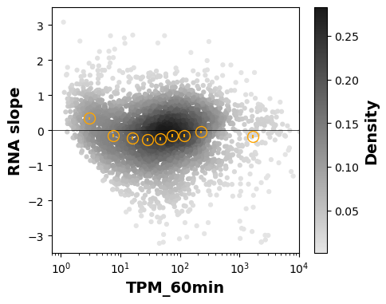

```python
min_val, max_val = 0.1,0.9
n = 10
orig_cmap = plt.cm.binary
colors = orig_cmap(np.linspace(min_val, max_val, n))
short_cmap = matplotlib.colors.LinearSegmentedColormap.from_list("mycmap", colors)
cmap_ = short_cmap

plot_df = rna_data[['RNA_slope', 'TPM_60min']]
plot_df = plot_df[~plot_df.TPM_60min.isnull()]
plot_df['log_TPM'] = np.log10(plot_df.TPM_60min)
plot_df['ion_bin'] = pd.qcut(plot_df.log_TPM, 9)
plot_df = plot_df[np.isfinite(plot_df.log_TPM)]

print(plot_df.shape[0], 'RNAs')
print(plot_df.sort_values('log_TPM').ion_bin.value_counts())

xone = plot_df.log_TPM
xtwo = plot_df.TPM_60min
yone = plot_df.RNA_slope
zone = density_scatter(xone, yone)
print(spearmanr(xone, yone))

plt.figure(figsize=(5,4))

plt.scatter(xtwo, yone, c=zone, s=12, cmap=cmap_)
mean_df = plot_df.groupby('ion_bin').mean()
std_df = plot_df.groupby('ion_bin').sem()
#     print(mean_df)
plt.errorbar(mean_df.TPM_60min, mean_df.RNA_slope, yerr=std_df.RNA_slope,
            marker='o', markersize=10, markerfacecolor='none',ls='none', color='orange')

plt.axhline([0], linewidth = 0.5, color='black')
cbar = plt.colorbar()
cbar.set_label('Density', rotation=90, fontsize=14, fontweight='bold')
plt.ylim(-3.5,3.5)
plt.xlim(0.7,10000)
plt.xscale('log')
plt.xlabel('TPM_60min', fontsize=14, fontweight='bold')
plt.ylabel('RNA slope', fontsize=14, fontweight='bold')
plt.show()
```

### The effects of the gene location around the origin on the protein slope

The circular distance of the gene from the *oriC* is plotted against the protein or the RNA slope. The average slope from two biological replicates is plotted for each gene.

```python
protein_slope_df = get_ion_intensity_and_ori_distance(prot_data_misc, protein_slope_df)
```

```python
def plot_ion_intensity_and_ori_distance_with_slope(slope_df, ion_bin_n, ori_bin_n, save_path):

    min_val, max_val = 0.1,0.9
    n = 10
    orig_cmap = plt.cm.binary
    colors = orig_cmap(np.linspace(min_val, max_val, n))
    short_cmap = matplotlib.colors.LinearSegmentedColormap.from_list("mycmap", colors)


    cmap_ = short_cmap

    plot_df = slope_df[slope_df.ion_intensity>0]
    plot_df = slope_df[~slope_df.ori_distance.isnull()]
    plot_df['ori_distance'] = plot_df.ori_distance/10**6
    plot_df['ori_bin'] = pd.qcut(plot_df.ori_distance, ori_bin_n)
    plot_df.replace([np.inf, -np.inf], np.nan, inplace=True)
    plot_df = plot_df[['ori_distance', 'mean_slope_1N', 'mean_slope_mltN', 'ori_bin']].dropna()
    print(plot_df.shape[0], 'proteins')
    print(plot_df.sort_values('ori_distance').ori_bin.value_counts())

    plt.figure(figsize=(10,4))
    gs = matplotlib.gridspec.GridSpec(1, 6, height_ratios=[1], width_ratios=[0.4,0.05,0.2]*2)
    gss = [plt.subplot(gs[0,0]),
           plt.subplot(gs[0,3])]
    one_axis = gss[0]
    two_axis = gss[1]

    one_axis.set_title('1N-rich cells', fontweight='bold', fontsize=14)

    xone = plot_df.ori_distance
    yone = plot_df.mean_slope_1N
    zone = density_scatter(xone, yone)

    im1 = one_axis.scatter(xone, yone, c=zone, s=12, cmap=cmap_)
    mean_df = plot_df.groupby('ori_bin').mean()
    std_df = plot_df.groupby('ori_bin').sem()
    one_axis.errorbar(mean_df.ori_distance, mean_df.mean_slope_1N, yerr=std_df.mean_slope_1N,
                marker='o', markersize=10, markerfacecolor='none',ls='none', color='orange')
    one_axis.axhline([0], linewidth=0.5, color='black')
    one_axis.set_xlabel('Circular distance\nfrom oriC (Mbps)', fontweight='bold', fontsize=14)
    one_axis.set_ylabel('Protein slope', fontweight='bold', fontsize=14)
    one_axis.set_ylim(-1.25,1.25)
    cbar_one = plt.colorbar(im1, cax=plt.subplot(gs[0,1]))
    cbar_one.set_label('Density', rotation=90, fontsize=14, fontweight='bold')
    fit_df = plot_df[plot_df.ori_distance<1.35]
    fit = np.polyfit(fit_df.ori_distance, fit_df.mean_slope_1N, 1)
    x_fit = np.arange(0,plot_df.ori_distance.max(),0.01)
    print('1N-rich', spearmanr(fit_df.ori_distance, fit_df.mean_slope_1N), 'Spearman r below 1.35')


    xone = plot_df.ori_distance
    yone = plot_df.mean_slope_mltN
    zone = density_scatter(xone, yone)

    two_axis.set_title('multi-N cells', fontweight='bold', fontsize=14)
    im2 = two_axis.scatter(xone, yone, c=zone, s=12, cmap=cmap_)
    mean_df = plot_df.groupby('ori_bin').mean()
    std_df = plot_df.groupby('ori_bin').sem()
    two_axis.errorbar(mean_df.ori_distance, mean_df.mean_slope_mltN, yerr=std_df.mean_slope_mltN,
                marker='o', markersize=10, markerfacecolor='none',ls='none', color='royalblue')
    two_axis.axhline([0], linewidth=0.5, color='black')
    print('multi-N', spearmanr(plot_df.ori_distance, plot_df.mean_slope_mltN))
    two_axis.set_ylabel('Protein slope', fontweight='bold', fontsize=14)
    two_axis.set_xlabel('Circular distance\nfrom oriC (Mbps)', fontweight='bold', fontsize=14)
    two_axis.set_ylim(-1.25,1.25)
    cbar_two = plt.colorbar(im2, cax=plt.subplot(gs[0,4]))
    cbar_two.set_label('Density', rotation=90, fontsize=14, fontweight='bold')
    if os.path.isdir(save_path):
        print('saving...')
        plt.savefig(save_path+'/distance_from_oriC.eps')

    plt.show()
```

```
2268 proteins
(-0.000626, 0.396]    378
(0.396, 0.764]        378
(0.764, 1.159]        378
(1.159, 1.53]         378
(1.53, 1.937]         378
(1.937, 2.32]         378
Name: ori_bin, dtype: int64
1N-rich SpearmanrResult(correlation=0.23076194195039143, pvalue=1.642392669783473e-17) Spearman r below 1.35
multi-N SpearmanrResult(correlation=0.05124900737970613, pvalue=0.014650027767731194)
```

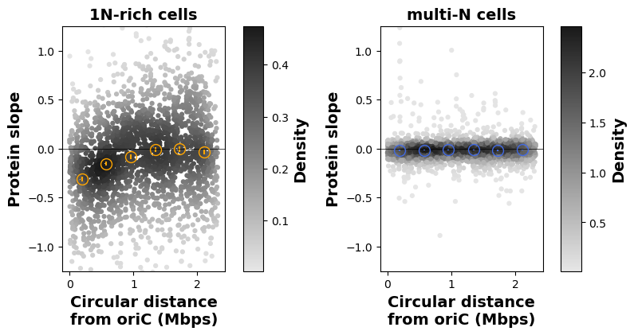

```python
plot_ion_intensity_and_ori_distance_with_slope(protein_slope_df, 6, 6, save_path_dir)
```

```python
def plot_tpm_and_ori_distance_with_slope(rna_data, ion_bin_n, ori_bin_n, save_path):

    min_val, max_val = 0.1,0.9
    n = 10
    orig_cmap = plt.cm.binary
    colors = orig_cmap(np.linspace(min_val, max_val, n))
    short_cmap = matplotlib.colors.LinearSegmentedColormap.from_list("mycmap", colors)
    cmap_ = short_cmap

    plot_df = rna_data.copy()
    plot_df = plot_df[~plot_df.circular_ori_distance.isnull()]
    plot_df['ori_distance'] = plot_df.circular_ori_distance/10**6
    plot_df['ori_bin'] = pd.qcut(plot_df.ori_distance, ori_bin_n)
    plot_df.replace([np.inf, -np.inf], np.nan, inplace=True)
    plot_df = plot_df[['ori_distance', 'RNA_slope', 'ori_bin']].dropna()
    print(plot_df.shape[0], 'RNAs')
    print(plot_df.sort_values('ori_distance').ori_bin.value_counts())

    xone = plot_df.ori_distance
    yone = plot_df.RNA_slope
    zone = density_scatter(xone, yone)
    print(spearmanr(xone, yone))

    plt.figure(figsize=(2.5,4))
    plt.scatter(xone, yone, c=zone, s=12, cmap=cmap_)
    mean_df = plot_df.groupby('ori_bin').mean()
    std_df = plot_df.groupby('ori_bin').sem()
    plt.errorbar(mean_df.ori_distance, mean_df.RNA_slope, yerr=std_df.RNA_slope,
                marker='o', markersize=10, markerfacecolor='none',ls='none', color='orange')
    cbar = plt.colorbar()
    cbar.set_label('Density', rotation=90, fontsize=14, fontweight='bold')
    plt.ylim(-2.5,2.5)
    plt.xlabel('Circular distance\nfrom oriC (Mbps)', fontweight='bold', fontsize=14)
    plt.ylabel('RNA slope', fontweight='bold', fontsize=14)
    if os.path.isdir(save_path):
        plt.savefig(save_path+'/oriC_distance_RNA_slope.eps')
    plt.show()
```

```python
rna_data = get_ori_distance_for_rna(prot_data_misc, rna_data)
```

```
2210 RNAs
(-0.000626, 0.395]    369
(1.932, 2.32]         369
(0.395, 0.764]        368
(0.764, 1.162]        368
(1.162, 1.529]        368
(1.529, 1.932]        368
Name: ori_bin, dtype: int64
SpearmanrResult(correlation=-0.0192309358639836, pvalue=0.36619129513741655)
```

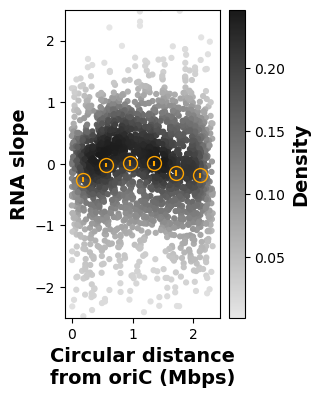

```python
plot_tpm_and_ori_distance_with_slope(rna_data.copy(), 6, 6, save_path_dir)
```